# Bang for your Buck Among the Best of the Best

Price analysis of top US coffee roasters

Drew Jones

### Introduction

I love coffee. I got into doing pourovers in 2021 and have not looked back since. Waking up and enjoying incredible filter coffee every morning is an essential part of my daily life, and has led to a number of wonderful experiences and strong friendships. When seeking out new coffees to try however, things can become complicated. The first is that there are more roasters than I could ever try in my life. Thankfully, Roastful assembled a list of the Top 100 Roasters in the world as selected by a panel of 32 industry experts. They will be the first to tell you the list is not definitive, however it does provide a good place to start seeking out excellent coffee.

##### Initial data manipulation

Although I would consider 12 oz to be teh most common bag size you might encounter in specialty coffee shops selling beans, in the supermarket, or online, only a few of the Top 100 roasters actually use it. In order to directly compare prices, I create the `adj_price` as 12 $\times$ $\frac{\text{price}}{\text{bag\_size}}$ . The purpose of this is to normalize the price per bag as though they all were 12 oz.

##### Data dictionary

Figure 1: Data Dictionary

| Variable | Description | Type | Class |
| --- | --- | --- | --- |
| roaster | Name of the coffee roaster | character | character |
| name | Name of the coffee offering | character | character |
| price | Shelf price, in USD | double | numeric |
| bag_size | Mass of the coffee in the bag, in OZ | double | numeric |
| origin_state | Origin country for single-origin coffee | character | character |
| origin_region | Geographic region in origin country | character | character |
| single | Dummy variable, yes indicates the coffee is single-origin and no indicates it is a blend | character | character |
| farm | Name of the producing farm, farmer, or washing station | character | character |
| importer | Name of coffee importer. NA indicates the roaster imported on its own | character | character |
| process | Coffee processing method | character | character |
| decaf | Dummy variable, yes indicates the coffee has been decaffeinated | character | character |
| decaf_process | Method of decaffeination used if applicable | character | character |
| varietal1 | First listed variety of coffee | character | character |
| varietal2 | Second listed variety of coffee | character | character |
| varietal3 | Third listed variety of coffee | character | character |
| varietal4 | Fourth listed variety of coffee | character | character |
| blend_state1 | First listed origin country for a blend | character | character |
| blend_state2 | Second listed origin country for a blend | character | character |
| blend_state3 | Third listed origin country for a blend | character | character |
| top100 | Dummy variable, yes indicates the roaster is on Roastful's Top 100 list | character | character |
| adj_price | Price normalized to 12 oz bag size | double | numeric |

Roaster websites vary greatly. There are a variety of naming conventions, levels of transparency, and accessibility of data on the coffees they sell. As a result, some of the observations have my subjective interpretations of data. `farm` is the farm the coffee was grown on, the name of the farmer who grew it, or the washing station that processed the coffee (the case for most African coffees). My entry follows that order, I named the farm if at all possible, but would settle for the specifc farmer or washing station if needed. `process` can vary from roaster to roaster. Passenger Coffee calls Natural Process “Dry” and Washed Process “Wet”, for example. There, I substituted the more common names. For the more complex, advanced processes, I tended to simplify them to braod terms like “Anaerobic Washed” even if the website said something like “92 Hour Extended Fermentation Experimental Washed”. Truly unique processes are included though, such as “Zero Fermentation” from Archetype Coffee.

Some roasters offer coffees in various size bags. I collected data on the size option that was closest to my 12 oz ideal. These roasters that sell 2 lbs bags certainly offer a greater value there, but that is not how I buy coffee.

### Exploratory Data Analysis

Figure 2: EDA for character variables

| skim_variable | n_missing | complete_rate | character.n_unique |
| --- | --- | --- | --- |
| roaster | 0 | 1.000000000 | 15 |
| name | 0 | 1.000000000 | 119 |
| origin_state | 1 | 0.991935484 | 17 |
| origin_region | 12 | 0.903225806 | 53 |
| single | 0 | 1.000000000 | 1 |
| farm | 23 | 0.814516129 | 88 |
| importer | 114 | 0.080645161 | 9 |
| process | 10 | 0.919354839 | 18 |
| decaf | 0 | 1.000000000 | 2 |
| decaf_process | 115 | 0.072580645 | 2 |
| varietal1 | 17 | 0.862903226 | 33 |
| varietal2 | 96 | 0.225806452 | 14 |
| varietal3 | 110 | 0.112903226 | 10 |
| varietal4 | 121 | 0.024193548 | 3 |
| blend_state1 | 123 | 0.008064516 | 1 |
| blend_state2 | 123 | 0.008064516 | 1 |
| blend_state3 | 123 | 0.008064516 | 1 |
| top100 | 0 | 1.000000000 | 1 |

In *Figure 2*, exploratory data analysis of the character variables are shown. There are 15 Top 100 Roasters in the US, and they featured a total of 119 single origin coffees during the data collection period. These coffees came from 88 producers in 17 different origin countries, were processed 18 different ways, and are made up of dozens of distinct varietals. High levels of missing values in `varietal2`, `varietal3` `varietal4` are explained by the fact that most coffees feature a single varietal.

Figure 3: EDA for numeric variables

| skim_variable | n_missing | complete_rate | numeric.mean | numeric.p0 | numeric.p25 | numeric.p50 | numeric.p75 | numeric.p100 | numeric.sd |
| --- | --- | --- | --- | --- | --- | --- | --- | --- | --- |
| price | 3 | 0.9758065 | 30.102479 | 14.0 | 22.00000 | 24.00000 | 28.00000 | 196.5 | 22.353796 |
| bag_size | 0 | 1.0000000 | 9.903805 | 3.5 | 8.81849 | 10.00000 | 10.50000 | 12.0 | 1.838486 |
| adj_price | 3 | 0.9758065 | 39.873195 | 20.0 | 24.00000 | 28.57632 | 34.01943 | 235.8 | 33.656227 |

*Figure 3* shows explatoratory data analysis for the numeric variables. There are 3 observations with missing values. These all come from Botz Coffee, where all menu options were sold out at the time of data collection, and at the time of writing. The median estimated price for a 12 oz bag is $28.57. The lowest adjusted price for a bag is $20 and the greatest is $235.80.

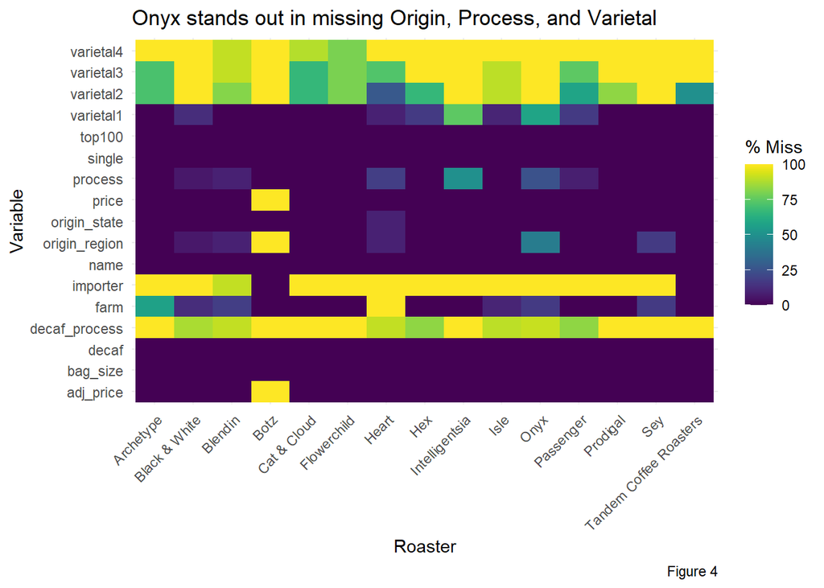

[figure not shown]

```r
# the missingness square
coffee_clean |>
  select( -blend_state1, -blend_state2, -blend_state3) |>
  gg_miss_fct(fct = roaster) +
  labs(
    x = "Roaster",
    y = "Variable",
    legend = "% Missing",
    title = "Onyx stands out in missing Origin, Process, and Varietal",
    caption = "Figure 4"
  )
```

Figure 6: Coffees over $100 for 12 oz

| adj_price | name | roaster | origin_state | process | varietal1 | varietal2 |
| --- | --- | --- | --- | --- | --- | --- |
| 235.80 | Familia Morales Rivera COE | Passenger | Ecuador | Anaerobic Washed | Sidra | Mejorado |
| 170.10 | El Paraiso Zeo | Archetype | Colombia | Zeo Drying | Geisha |  |
| 168.00 | Tio Conejo | Onyx | Colombia | Natural | Geisha |  |
| 157.71 | Finca La Mula | Blendin | Panama | Natural | Geisha |  |
| 120.00 | La Negrita | Blendin | Colombia | Anaerobic Natural | Wush Wush |  |
| 106.20 | Familia Morales Rivera | Passenger | Ecuador | Anaerobic Washed | Sidra | Mejorado |
| 102.86 | Gesha Village | Blendin | Ethiopia | Natural | Geisha |  |

Some of these coffees are priced so highly due to the technical details of their processing. El Paraiso Zeo from Archetype Coffee was processed in a way I was completely unfamiliar with, “Zeo Drying.” I labeled La Negrita from Blending Coffee Club as “Anaerobic Natural,” however the website details further steps outside of the standard Anaerobic Natural, suggesting the time, energy, and money to prodcue these beans is especially high as well.

As for the rest, these are coffees that come from highly respected farms with pedigree growing for brewing competitions. Gesha Village, for example, is one of the only truly micro-lot growing farms in Ethiopia.

Figure 7: Prodigal stands out as the most expensive

| roaster | median_adj_price | mean_adj_price |
| --- | --- | --- |
| Prodigal | 63.95653 | 60.78140 |
| Flowerchild | 34.01943 | 42.04802 |
| Sey | 33.16894 | 33.11224 |
| Isle | 31.29788 | 36.60491 |
| Intelligentsia | 31.00000 | 29.00000 |
| Blendin | 30.00000 | 60.12468 |
| Hex | 29.25000 | 28.40000 |
| Onyx | 28.80000 | 50.75000 |
| Black & White | 28.00000 | 32.37500 |
| Archetype | 27.60000 | 51.04242 |
| Heart | 26.28571 | 25.35065 |
| Cat & Cloud | 26.10000 | 26.05333 |
| Passenger | 25.65000 | 50.55000 |
| Tandem Coffee Roasters | 22.00000 | 22.16667 |